# Взаимодействие дискретных и непрерывных предикторов

## Мы рассмотрим

- Линейные модели c непрерывными и дискретными предикторами
- Взаимодействие дискретных и непрерывных предикторов

## Геометрическая интерпретация коэффициентов регрессии

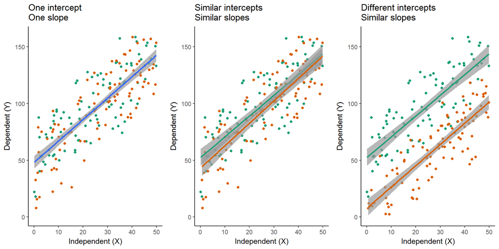

## Но ведь может быть еще и так

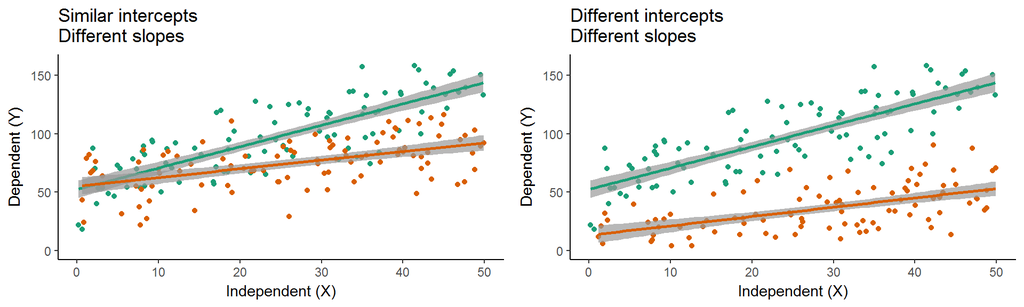

- Как все эти изменения закодировать в уравнении линейной модели?

## Похожий интерсепт, похожий угол наклона

Если зависимости для обеих групп выглядят одинаково, то мы можем пользоваться общей линейной регрессией, не учитывать группу

\(Y = b_0 + b_1X\)

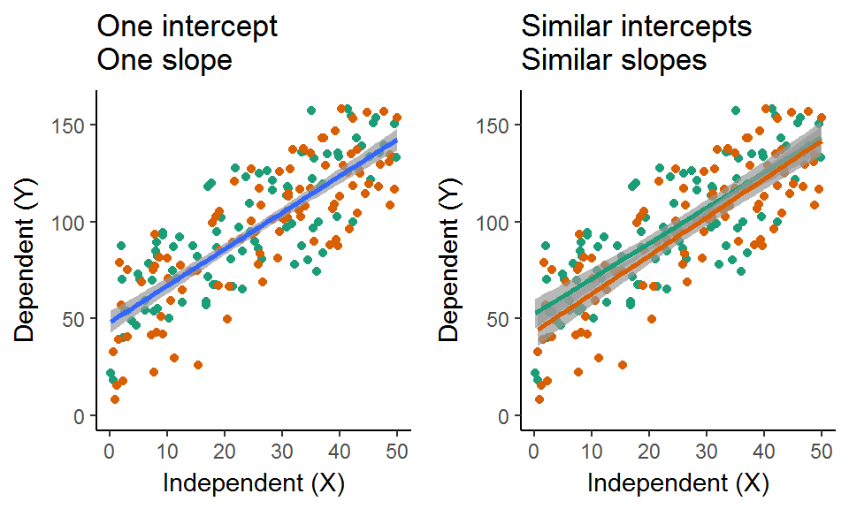

## Разный интерсепт, похожий угол наклона

\(Y = b_0 + b_1X + b_2 I_{Group2}\)

\(I_{Group2} = 1\) если наблюдение из группы 2, и \(I_{Group2} = 0\) в остальных случаях

Уравнение для группы 1: \(Y = b_0 + b_1X + b_2\cdot0\)

Уравнение для группы 2: \(Y = b_0 + b_1X + b_2\cdot1 =(b_0 + b_2) + b_1X\)

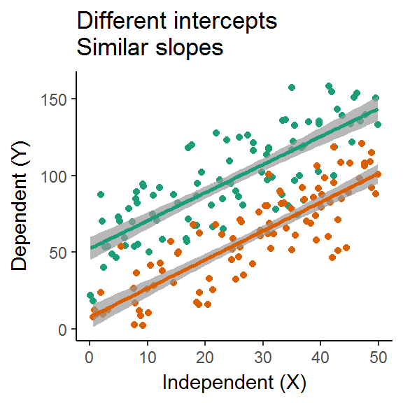

## Похожий интерсепт, разный угол наклона

\(Y = b_0 + b_1X + b_2X\cdot I_{Group2}\)

\(I_{Group2}\) если наблюдение из группы 2, и \(I_{Group2} = 0\) в остальных случаях

Уравнение для группы 1: \(Y = b_0 + b_1X + b_2X \cdot 0 = b_0 + b_1X\)

Уравнение для группы 2: \(Y = b_0 + b_1X + b_2X \cdot 1 = b_0 + (b_1 + b_2)X\)

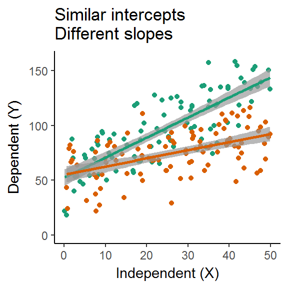

## Разный интерсепт и разный угол наклона

\(Y = b_0 + b_1X + b_2 \cdot I_{Group2} + b_3X \cdot I_{Group2}\)

\(I_{Group2} = 1\) если наблюдение из группы 2, и \(I_{Group2} = 0\) в остальных случаях

Уравнение для группы 1: \(Y = b_0 + b_1X + b_2 \cdot 0 + b_3X \cdot 0 = b_0 + b_1X\)

Уравнение для группы 2: \(Y = b_0 + b_1X + b_2 \cdot 1 + b_3X \cdot 1 = (b_0 + b_2) + (b_1 + b_3)X\)

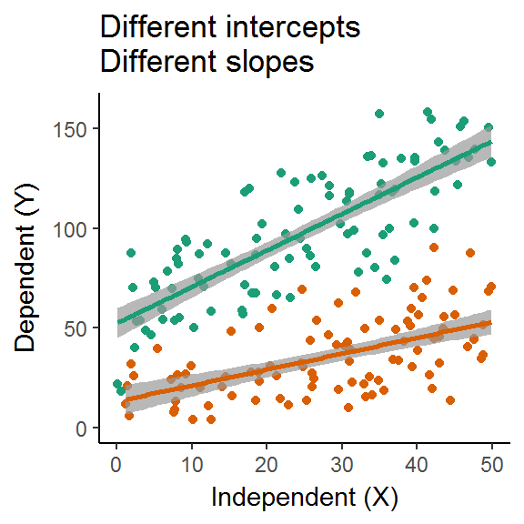

## Физический смысл взаимодействия факторов

Не называйте взаимодействие факторов "корреляцией" или "связью"!

Взаимодействие факторов означает, что для разных значений одного из факторов зависимость от другого фактора выглядит по-разному.

Т.е. в данном случае можно сказать: "Для группы 1 и группы 2 зависимость Y от Х выглядит по-разному"

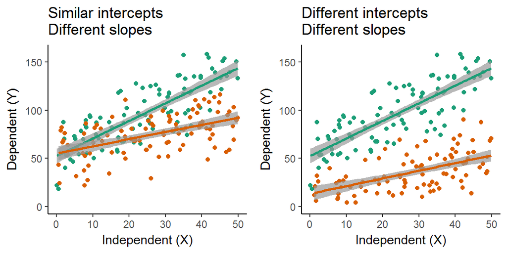

## Если у дискретного предиктора становится больше уровней…

\[y_i = \beta_0 + \beta_1x_1 + \big(\beta_2x_2 + ... + \beta_l x_l\big) + \big(\beta_{l+1}x_{l+1} + ... + \beta_m x_m\big) + \epsilon_i\]

В случае, **если у дискретного фактора \(k\) градаций**, уравнение полной модели будет включать несколько групп коэффициентов:

- \(\beta_0\) — значение свободного члена для базового уровня дискретного фактора
- \(\beta_1\) — коэффициент угла наклона для базового уровня дискретного фактора

Поправки для свободного члена:

- \(\beta_2, ..., \beta_l\) — коррекция свободного члена для других уровней (всего их \(p = k - 1\))

Поправки для угла наклона:

- \(\beta_{l+1}, ..., \beta_m\) — коррекция коэффициентов угла наклона для других уровней (всего их \(p = k - 1\))

## Модель со взаимодействием на примере данных о весе новорожденных

## Вес новорожденных и курение

Как вес новорожденных зависит от возраста матери и того, курит ли она

```r
wt <- read.table("data/birthwt.csv", header = TRUE, sep = ";")
```

## Задание

- Исследуйте данные о весе новорожденных
- Постройте модель зависимости веса новорожденных от возраста матери, того курит она или нет и взаимодействия предикторов
- Проверьте условия применимости этой модели
- Упростите модель, если это возможно
- Напишите общее уравнение и отдельные уравнения модели
- Постройте график предсказаний модели

## Решение

```r
str(wt)
```

```
## 'data.frame':    189 obs. of  9 variables:
##  $ age  : int  19 33 20 21 18 21 22 17 29 26 ...
##  $ lwt  : int  182 155 105 108 107 124 118 103 123 113 ...
##  $ race : int  2 3 1 1 1 3 1 3 1 1 ...
##  $ smoke: int  0 0 1 1 1 0 0 0 1 1 ...
##  $ ptl  : int  0 0 0 0 0 0 0 0 0 0 ...
##  $ ht   : int  0 0 0 0 0 0 0 0 0 0 ...
##  $ ui   : int  1 0 0 1 1 0 0 0 0 0 ...
##  $ ftv  : int  0 3 1 2 0 0 1 1 1 0 ...
##  $ bwt  : int  2523 2551 2557 2594 2600 2622 2637 2637 2663 2665 ...
```

```r
colSums(is.na(wt))
```

```
##   age   lwt  race smoke   ptl    ht    ui   ftv   bwt
##     0     0     0     0     0     0     0     0     0
```

```r
table(wt$smoke, wt$age)
```

```
##
##     14 15 16 17 18 19 20 21 22 23 24 25 26 27 28 29 30 31 32 33 34 35
##   0  2  3  5  7  3  8 10  7  8  9 10 12  3  2  5  4  5  2  4  2  0  1
##   1  1  0  2  5  7  8  8  5  5  4  3  3  5  1  4  3  2  3  2  1  1  1
##
##     36 45
##   0  2  1
##   1  0  0
```

```r
table(wt$smoke, wt$race)
```

```
##
##      1  2  3
##   0 44 16 55
##   1 52 10 12
```

```r
table(wt$smoke, wt$ui)
```

```
##
##       0   1
##   0 100  15
##   1  61  13
```

## Решение

```r
wt$race <- factor(wt$race)
wt$smoke <- factor(wt$smoke)
wt$ptl <- factor(wt$ptl)
wt$ht <- factor(wt$ht)
wt$ui <- factor(wt$ui)
wt$ftv <- factor(wt$ftv)
```

## Решение

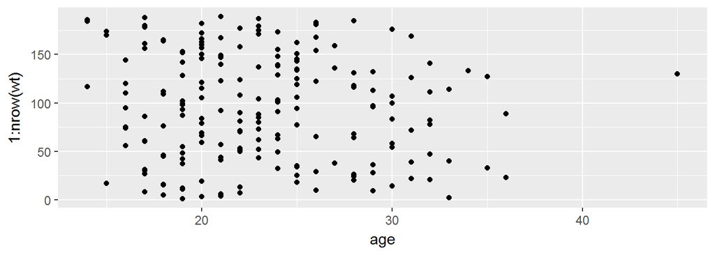

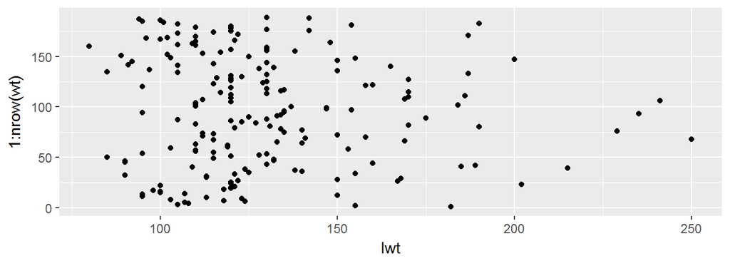

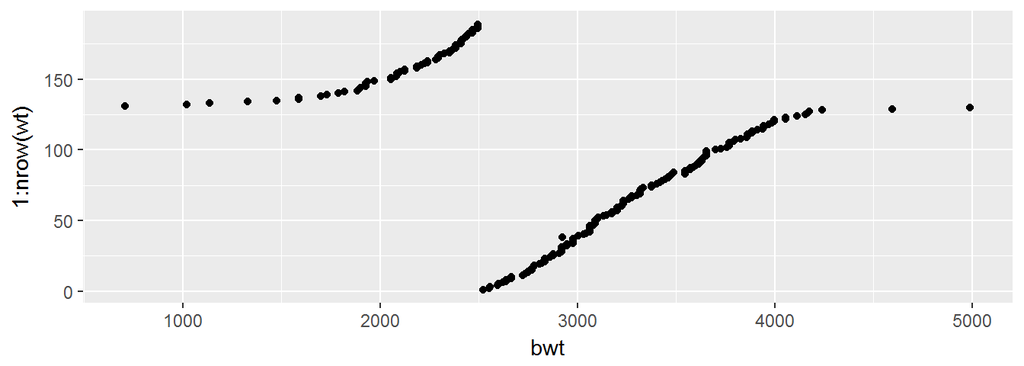

```r
gg_dot <- ggplot(wt, aes(y = 1:nrow(wt))) + geom_point()
gg_dot + aes(x = age)
gg_dot + aes(x = lwt)
gg_dot + aes(x = bwt)
```

## Решение

### Проверка на колинеарность

```r
wt_mod_1 <- lm(bwt ~ age+smoke, data = wt)
vif(wt_mod_1)
```

```
##   age smoke
##     1     1
```

- Колинеарности нет

## Проверка на гомогенность углов наклона

Подберем полную модель.

```r
wt_mod_2 <- lm(bwt ~ age*smoke, data = wt)
drop1(wt_mod_2, test = "F")
```

```
## Single term deletions
##
## Model:
## bwt ~ age * smoke
##           Df Sum of Sq      RSS  AIC F value Pr(>F)
## <none>                 93062605 2485
## age:smoke  1   2609683 95672288 2488    5.19  0.024 *
## ---
## Signif. codes:  0 '***' 0.001 '**' 0.01 '*' 0.05 '.' 0.1 ' ' 1
```

- От исключения взаимодействия модель становится значительно хуже. Оставляем

## Решение

```r
# Данные для графиков остатков
wt_mod_2_diag <- fortify(wt_mod_2)
wt_mod_2_diag <- data.frame(
  wt_mod_2_diag,
  wt[, c("lwt", "race", "smoke", "ptl", "ht", "ui", "ftv")])
```

### 1) График расстояния Кука

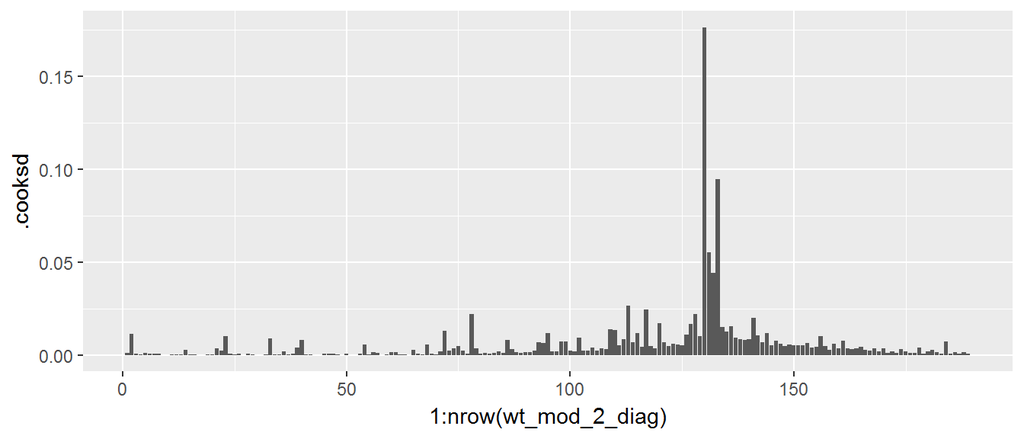

```r
ggplot(wt_mod_2_diag, aes(x = 1:nrow(wt_mod_2_diag), y = .cooksd)) +
  geom_bar(stat = "identity")
```

## Решение

### 2) График остатков от предсказанных значений

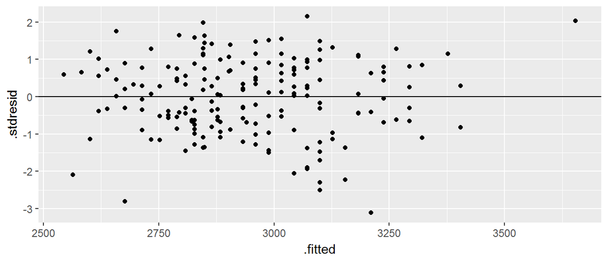

```r
gg_resid <- ggplot(data = wt_mod_2_diag, aes(x = .fitted, y = .stdresid)) +
  geom_point() + geom_hline(yintercept = 0)
gg_resid
```

## Решение

### 3) Графики остатков от предикторов в модели и не в модели

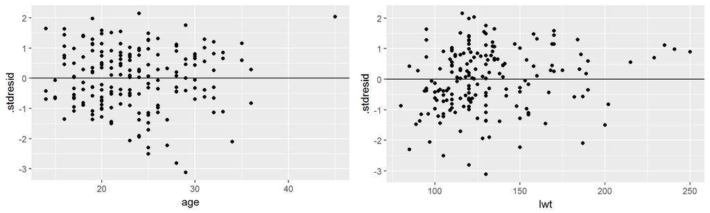

```r
library(gridExtra)
grid.arrange(gg_resid + aes(x = age),
             gg_resid + aes(x = lwt),
             nrow = 1)
```

## Решение

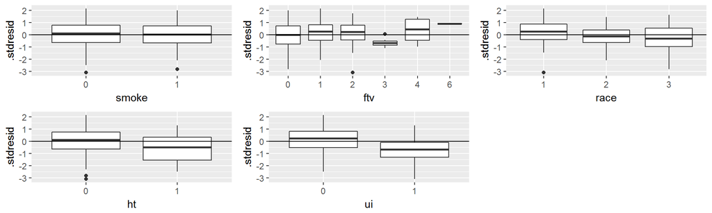

```r
gg_box <- ggplot(data = wt_mod_2_diag, aes(x = smoke, y = .stdresid)) +
  geom_boxplot() + geom_hline(yintercept = 0)

grid.arrange(gg_box + aes(x = smoke),
             gg_box + aes(x = ftv),
             gg_box + aes(x = race),
             gg_box + aes(x = ht),
             gg_box + aes(x = ui),
             nrow = 2)
```

## Решение

### 4) Квантильный график остатков

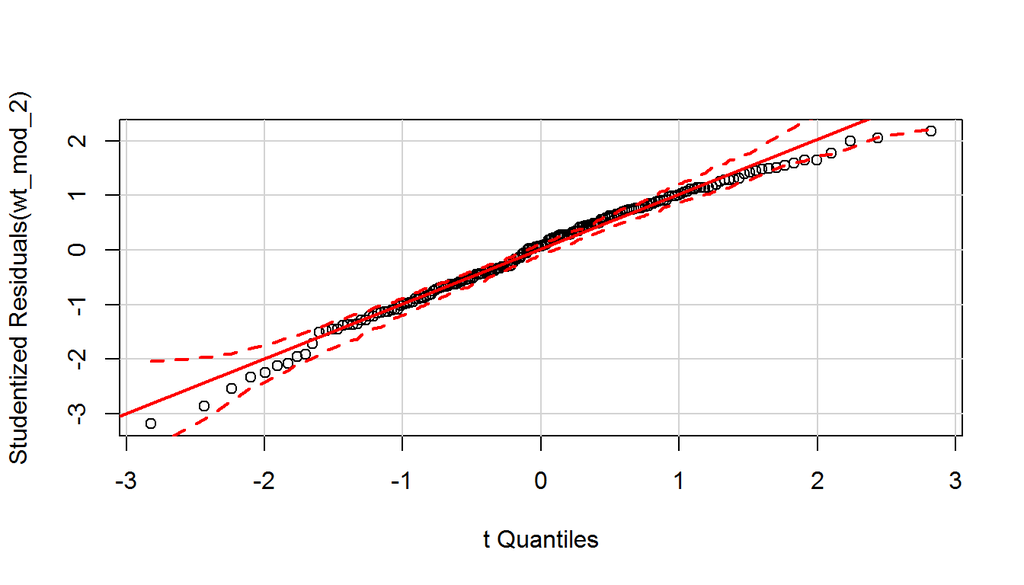

```r
qqPlot(wt_mod_2)
```

## Проверяем значимость коэффициентов

Подумайте, что означают эти коэффициенты

```r
summary(wt_mod_2)
```

```
##
## Call:
## lm(formula = bwt ~ age * smoke, data = wt)
##
## Residuals:
##     Min      1Q  Median      3Q     Max
## -2189.3  -458.5    51.5   527.3  1521.4
##
## Coefficients:
##             Estimate Std. Error t value Pr(>|t|)
## (Intercept)   2406.1      292.2    8.23  3.2e-14 ***
## age             27.7       12.1    2.28    0.024 *
## smoke1         798.2      484.3    1.65    0.101
## age:smoke1     -46.6       20.4   -2.28    0.024 *
## ---
## Signif. codes:  0 '***' 0.001 '**' 0.01 '*' 0.05 '.' 0.1 ' ' 1
##
## Residual standard error: 709 on 185 degrees of freedom
## Multiple R-squared:  0.0691, Adjusted R-squared:  0.054
## F-statistic: 4.58 on 3 and 185 DF,  p-value: 0.00407
```

## Записываем уравнение модели

```r
coef(wt_mod_2)
```

```
## (Intercept)         age      smoke1  age:smoke1
##      2406.1        27.7       798.2       -46.6
```

Общее уравнение:

bwt = 2406.06 + 27.73age + 798.17smoke1 - 46.57age:smoke1

## Таблица дисперсионного анализа

```r
Anova(wt_mod_2, type = 3)
```

```
## Anova Table (Type III tests)
##
## Response: bwt
##               Sum Sq  Df F value  Pr(>F)
## (Intercept) 34110331   1   67.81 3.2e-14 ***
## age          2620946   1    5.21   0.024 *
## smoke        1366143   1    2.72   0.101
## age:smoke    2609683   1    5.19   0.024 *
## Residuals   93062605 185
## ---
## Signif. codes:  0 '***' 0.001 '**' 0.01 '*' 0.05 '.' 0.1 ' ' 1
```

## Сложные модели лучше по возможности изображать в виде графика

### Данные для графика

```r
library(plyr)
# Диапазон возрастов разный для курящих и некурящих, поэтому
NewData <- ddply(
  .data = wt, .variables = .(smoke), .fun = summarise,
  age = seq(min(age), max(age), length = 100))

# предсказанные значения
Predictions <- predict(wt_mod_2, newdata = NewData, se.fit = TRUE)
NewData$fit <- Predictions$fit
# стандартные ошибки
NewData$SE <- Predictions$se.fit
# доверительный интервал
NewData$upr <- NewData$fit + 1.96 * NewData$SE
NewData$lwr <- NewData$fit - 1.96 * NewData$SE
```

## Рисуем график предсказаний

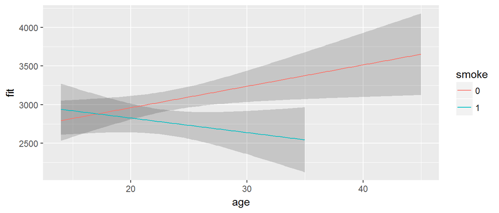

```r
ggplot(NewData, aes(x = age, y = fit)) +
  geom_ribbon(alpha = 0.2, aes(ymin = lwr, ymax = upr, group = smoke)) +
  geom_line(aes(colour = smoke))
```

## На графике предсказаний можно показать исходные значения

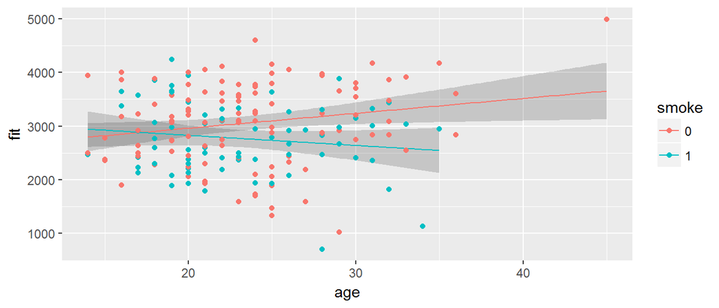

```r
ggplot(NewData, aes(x = age, y = fit)) +
  geom_ribbon(alpha = 0.2, aes(ymin = lwr, ymax = upr, group = smoke)) +
  geom_line(aes(colour = smoke)) +
  geom_point(data = wt, aes(x = age, y = bwt, colour = smoke))
```

## Take home messages

- У дискретных и непрерывных факторов могут быть взаимодействия, поэтому анализ нужно начинать с более полной модели (чтобы можно было протестировать и исключить недостоверные взаимодействия)

## Что почитать

- Must read paper! Zuur, A.F. and Ieno, E.N., 2016. A protocol for conducting and presenting results of regression‐type analyses. Methods in Ecology and Evolution, 7(6), pp.636-645.
- Кабаков Р.И. R в действии. Анализ и визуализация данных на языке R. М.: ДМК Пресс, 2014
- Zuur, A., Ieno, E.N. and Smith, G.M., 2007. Analyzing ecological data. Springer Science & Business Media.
- Quinn G.P., Keough M.J. 2002. Experimental design and data analysis for biologists
- Logan M. 2010. Biostatistical Design and Analysis Using R. A Practical Guide